# Reproducible Research - Course project 1

Adrian R Angkawijaya

5/19/2018

## *Loading and preprocessing the data*

```r
setwd("/Users/adrianromano/Downloads")
activity <- read.csv("activity.csv")
str(activity)
```

```
## 'data.frame':    17568 obs. of  3 variables:
##  $ steps   : int  NA NA NA NA NA NA NA NA NA NA ...
##  $ date    : Factor w/ 61 levels "2012-10-01","2012-10-02",..: 1 1 1 1 1 1 1 1 1 1 ...
##  $ interval: int  0 5 10 15 20 25 30 35 40 45 ...
```

```r
activity$date <- as.Date(activity$date)
```

## *What is mean total number of steps taken per day?*

1. **Calculate the total number of steps taken per day**

```r
library(plyr)
totalSteps <- aggregate(activity$steps ~ activity$date, FUN = sum)
colnames(totalSteps) <- c("Date", "Steps")
head(totalSteps)
```

```
##         Date Steps
## 1 2012-10-02   126
## 2 2012-10-03 11352
## 3 2012-10-04 12116
## 4 2012-10-05 13294
## 5 2012-10-06 15420
## 6 2012-10-07 11015
```

2. **Histogram of the total number of steps taken per day**

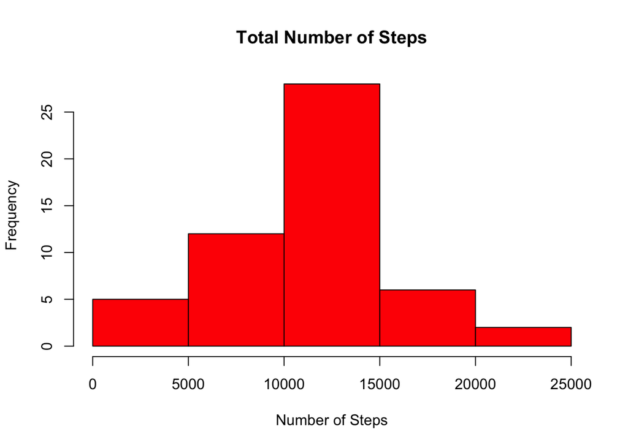

```r
hist(totalSteps$Steps, main = "Total Number of Steps", xlab = "Number of Steps", col = "red")
```

3. **Calculate the mean and median of the total number of steps taken per day**

```r
meanSteps <- mean(totalSteps$Steps, na.rm = TRUE)
meanSteps
```

```
## [1] 10766.19
```

```r
medianSteps <- median(totalSteps$Steps, na.rm = TRUE)
medianSteps
```

```
## [1] 10765
```

- mean: 10766.19
- median: 10765

## *What is the average daily activity pattern?*

1. **Create a time series plot of the 5-minute interval and the average number of steps taken averaged across all days**

```r
averageSteps <- aggregate(activity$steps ~ activity$interval, FUN = mean, na.rm = TRUE)
colnames(averageSteps) <- c("Interval", "Steps")
head(averageSteps)
```

```
##   Interval     Steps
## 1        0 1.7169811
## 2        5 0.3396226
## 3       10 0.1320755
## 4       15 0.1509434
## 5       20 0.0754717
## 6       25 2.0943396
```

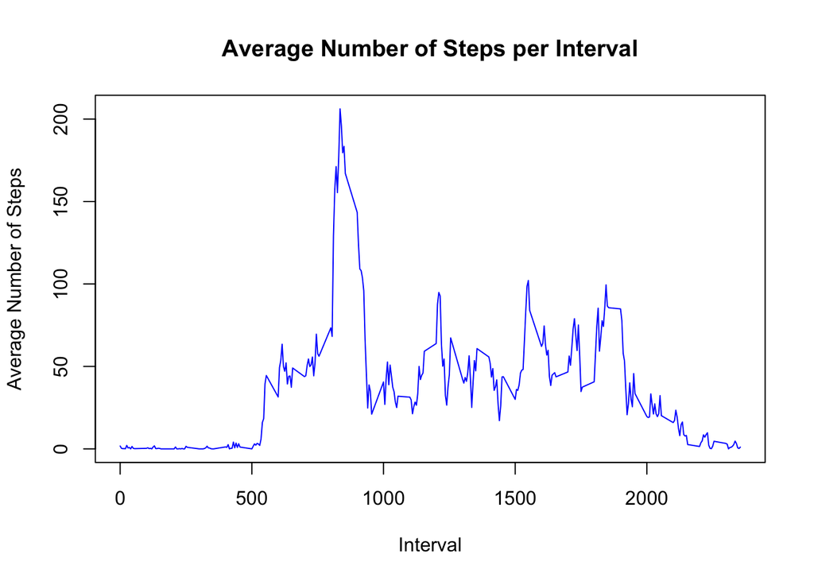

```r
plot(averageSteps$Steps ~ averageSteps$Interval,
                        type = "l",
                        col = "blue",
                        main = "Average Number of Steps per Interval",
                        xlab = "Interval",
                        ylab = "Average Number of Steps")
```

2. **Look at the maximum number of steps for the average 5-minute interval across all days**

```r
maxSteps <- averageSteps[which.max(averageSteps$Steps),]
maxSteps
```

```
##     Interval    Steps
## 104      835 206.1698
```

- *Interval 835 has the maximum number of steps of 206.1698 for the average 5-minute interval across all days*

## *Imputing missing values*

1. **Look at the number of missing values in the data**

```r
sum(is.na(activity))
```

```
## [1] 2304
```

- *Total number of missing values is 2304*
2. **Replace NA Values with the mean average steps per interval**

```r
meanPerInterval <- mean(averageSteps$Steps, na.rm = TRUE)
activity1 <- activity
activity1$steps[is.na(activity1$steps)] <- meanPerInterval
```

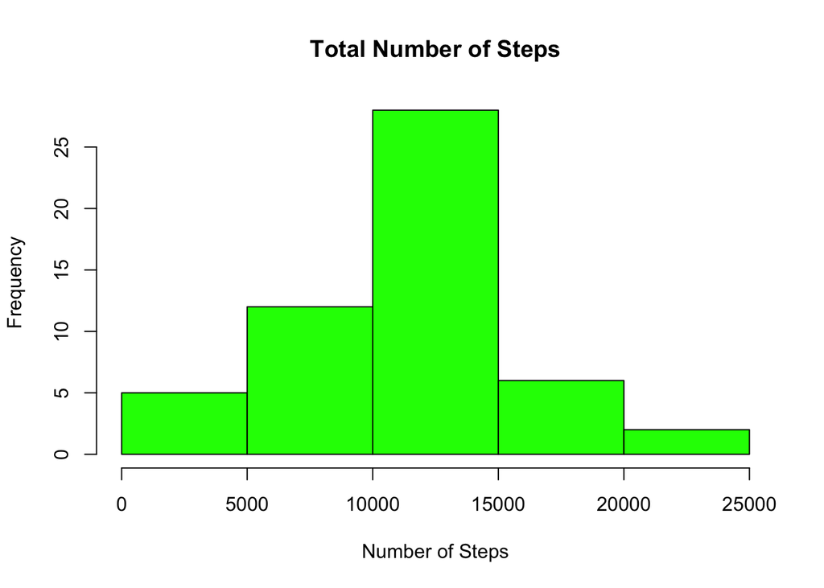

```r
totalSteps1 <- aggregate(activity1$steps ~ activity1$date, FUN = sum)
colnames(totalSteps1) <- c("Date", "Steps")
hist(totalSteps$Steps, main = "Total Number of Steps", xlab = "Number of Steps", col = "green")
```

4. **Calculate the mean and median of the total number of steps taken each day after missing values were imputed**

```r
meanSteps1 <- mean(totalSteps1$Steps)
meanSteps1
```

```
## [1] 10766.19
```

```r
medianSteps1 <- median(totalSteps1$Steps)
medianSteps1
```

```
## [1] 10766.19
```

- mean: 10766.19
- median: 10766.19
- *Replacing the missing values did not have any change in the mean value and a slight increase in median value*

## *Are there differences in activity patterns between weekdays and weekends?*

1. **Create a new factor variable cating whether a given date is a weekday or weekend day**

```r
activity1$date <- as.Date(activity1$date)
activity1$dayCategory <- ifelse(weekdays(activity1$date) == "Saturday" | weekdays(activity1$date) == "Sunday", "Weekend", "Weekday")
averageDayCategory <- aggregate(activity1$steps ~ activity1$dayCategory + activity1$interval, FUN = mean)
colnames(averageDayCategory) <- c("DayType", "Interval", "Steps")
head(averageDayCategory)
```

```
##   DayType Interval    Steps
## 1 Weekday        0 7.006569
## 2 Weekend        0 4.672825
## 3 Weekday        5 5.384347
## 4 Weekend        5 4.672825
## 5 Weekday       10 5.139902
## 6 Weekend       10 4.672825
```

2. **Make a panel plot containing a time series plot of the 5-minute interval and the average number of steps taken, averaged across all weekday days or weekend days**

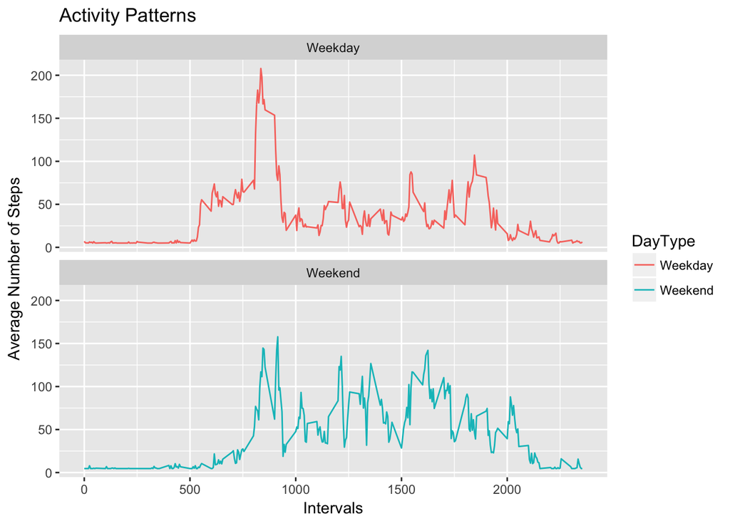

```r
library(ggplot2)
p <- ggplot(averageDayCategory, aes(Interval, Steps, color = DayType))
p + geom_line() + labs(x = "Intervals", y = "Average Number of Steps", title = "Activity Patterns") + facet_wrap(~DayType,ncol=1,nrow=2)
```